# Dimensionality Reduction

### Module 9: Dimensionality Reduction

Note: In this question, all columns will be written in their transposed form, as rows, to make the typography simpler. Matrix M has three rows and three columns, and the columns form an orthonormal basis. One of the columns is [2/7,3/7,6/7], and another is [6/7, 2/7, -3/7]. Let the third column be [x,y,z]. Since the length of the vector [x,y,z] must be 1, there is a constraint that x^2+y^2+z^2 = 1. However, there are other constraints, and these other constraints can be used to deduce facts about the ratios among x, y, and z. Compute these ratios.

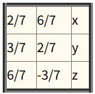

```python
from IPython.display import Image
Image(filename='matrix5.png')
```

```python
import numpy as np
from fractions import Fraction

# If the columns of a matrix M are orthonormal,
# M @ M.T = I, the identity matrix.
# This means that the inverse of M is its transpose,
# so the rows of the matrix are also orthonormal.

x = np.sqrt(1 - (2/7)**2 - (6/7)**2)
y = np.sqrt(1 - (3/7)**2- (6/7)**2)
z = np.sqrt(1 - (6/7)**2 - (-3/7)**2)
print('x: +/- {}'.format(Fraction(x).limit_denominator()))
print('y: +/- {}'.format(Fraction(y).limit_denominator()))
print('z: +/- {}'.format(Fraction(z).limit_denominator()))
```

```
x: +/- 3/7
y: +/- 2/7
z: +/- 2/7
```

Find the eigenvalues and eigenvectors of the following matrix:

```python
Image(filename='matrix6.png')
```

[output not shown]

You should assume the first component of an eigenvector is 1.

```python
matrix = np.array([[2,  3],
                   [3, 10]])

eigenvalues, eigenvectors = np.linalg.eig(matrix)
normalized_eigenvectors = [evec * 1/evec[0] for evec in eigenvectors]
print('Eigenvalues: {}'.format(eigenvalues))
print('Eigenvectors: {}'.format(normalized_eigenvectors))
```

```
Eigenvalues: [ 1. 11.]
Eigenvectors: [array([1.        , 0.33333333]), array([ 1., -3.])]
```

Suppose [1,3,4,5,7] is an eigenvector of some matrix. What is the unit eigenvector in the same direction?

```python
eigenvector = np.array([1, 3, 4, 5, 7])
magnitude = np.linalg.norm(eigenvector)
print('Unit Eigenvector: {}'.format(eigenvector / magnitude))
```

```
Unit Eigenvector: [0.1 0.3 0.4 0.5 0.7]
```

Suppose we have three points in a two dimensional space: (1,1), (2,2), and (3,4). We want to perform PCA on these points, so we construct a 2-by-2 matrix, call it N, whose eigenvectors are the directions that best represent these three points. Construct the matrix N.

```python
points = np.array([[1, 1],
                   [2, 2],
                   [3, 4]])

# The idea behind PCA is to treat the set of points as
# a matrix M and find the eigenvectors for M @ M.T or M.T @ M
print(points.T @ points)
```

```
[[14 17]
 [17 21]]
```

Consider the diagonal matrix M =

```python
Image(filename='matrix7.png')
```

[output not shown]

Compute its Moore-Penrose pseudoinverse.

```python
matrix = np.array([[1, 0, 0],
                   [0, 2, 0],
                   [0, 0, 0]])

pseudoinverse = np.linalg.pinv(matrix)
print('Pseudoinverse: {}'.format(pseudoinverse.tolist()))
```

```
Pseudoinverse: [[1.0, 0.0, 0.0], [0.0, 0.5, 0.0], [0.0, 0.0, 0.0]]
```

When we perform a CUR dcomposition of a matrix, we select rows and columns by using a particular probability distribution for the rows and another for the columns. Here is a matrix that we wish to decompose:

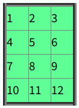

```python
Image(filename='matrix8.png')
```

Calculate the probability distribution for the rows.

```python
matrix = np.array([[ 1,  2,  3],
                   [ 4,  5,  6],
                   [ 7,  8,  9],
                   [10, 11, 12]])

frobenius_norm = np.linalg.norm(matrix, ord='fro')
sum_of_squares = frobenius_norm ** 2

for row in matrix:
    probability = np.linalg.norm(row) ** 2 / sum_of_squares
    print('Probability for row {}: {:.2}'.format(row, probability))
```

```
Probability for row [1 2 3]: 0.022
Probability for row [4 5 6]: 0.12
Probability for row [7 8 9]: 0.3
Probability for row [10 11 12]: 0.56
```